# Chapter 11: Classes and Constructors

ENG3091

Author

Affiliation

Khiem Nguyen

University of Glasgow

# 1 Member access

## 1.1 Public and private

In Chapter 10 we used `struct`s everywhere, which showed that a `struct` is almost the same as a `class`. The one difference that matters here:

- the members of a `struct` are **public** by default;
- the members of a `class` are **private** by default.

Now let’s see what `public` and `private` actually mean.

## 1.2 An analogy

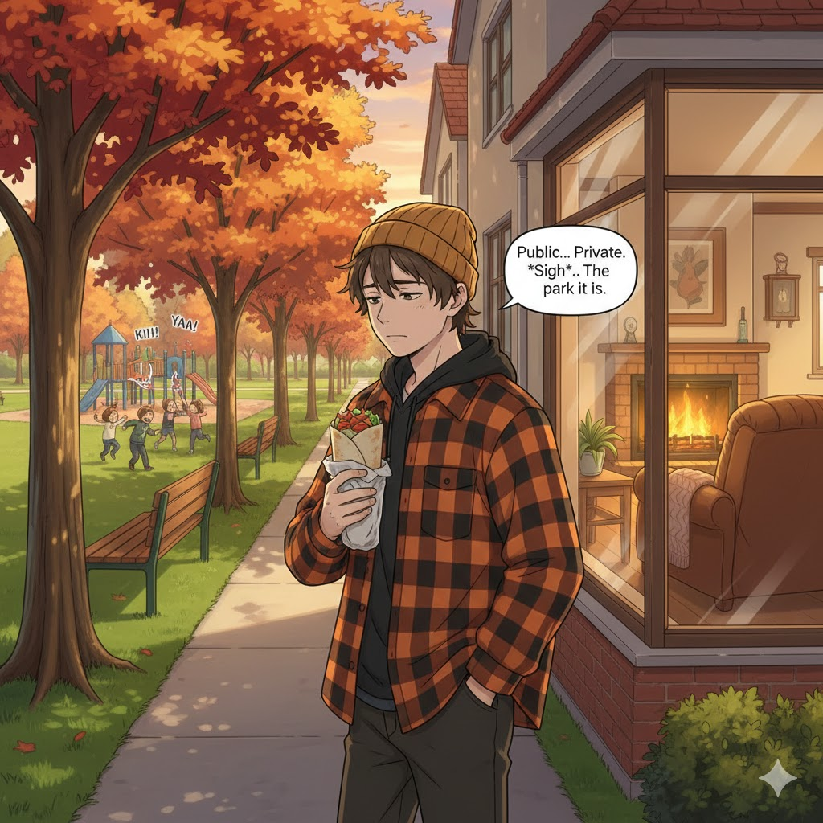

It’s not about what you want; it’s about what you’re allowed to do.

## 1.3 Access levels

Every member of a class type has an **access level**, which decides who may use it:

1. `public`: anyone;
2. `private`: only the class’s own members;
3. `protected`: we’ll meet this one in Chapter 14, with inheritance.

Code that isn’t a member of the class, like `main()`, is called **the public**.

## 1.4 Members of a `struct` are public by default

```
struct_public_by_default.cpp
```

```cpp
#include <iostream>

struct Date {
    int year{}, month{}, day{}; // public by default

    void print() const { // public by default
        std::cout << year << '/' << month << '/' << day << '\n';
    }
};

int main() { // main() is not a member: it's "the public"
    Date today{2026, 2, 26};
    today.day = 42;   // allowed: day is public...
    today.month = 42; // ...so nothing stops nonsense like this
    today.year = -42;
    today.print();
    return 0;
}
```

```
-42/42/42
```

A **public member** can be used by anyone: by the class’s own members, and by the public. Nothing stops this nonsense date.

## 1.5 Members of a `class` are private by default

```
class_private_by_default.cpp
```

```cpp
#include <iostream>

class Date { // now a class: members are private by default
    int year{}, month{}, day{};

    void print() const {
        std::cout << year << '/' << month << '/' << day << '\n';
    }
};

int main() {
    Date today{2026, 2, 26}; // error: not an aggregate any more
    today.day = 42;          // error: day is private
    today.print();           // error: print() is private
    return 0;
}
```

```
error: no matching function for call to 'Date::Date(<brace-enclosed initializer list>)'
error: 'int Date::day' is private within this context
error: 'void Date::print() const' is private within this context
```

A **private member** can only be used by other members of the same class, never by the public.

## 1.6 Setting access levels with access specifiers

```
access_specifier_example.cpp
```

```cpp
#include <iostream>

class Date {
  public:                // everything below is public...
    void print() const { // members may use private members
        std::cout << year << '/' << month << '/' << day << '\n';
    }

  private: // ...and everything below is private
    int year{2026};
    int month{2};
    int day{26};
};

int main() {
    Date today{};
    today.print(); // fine: print() is public
    return 0;
}
```

```
2026/2/26
```

An **access specifier**, `public:`, `private:` or `protected:`, sets the access level of every member that follows it.

The usual layout: the **public interface** first (what users of the class need), then the **private** details.

## 1.7 Access levels at a glance

| Access level | Specifier | Members of the class | Derived classes | The public |
| --- | --- | --- | --- | --- |
| Public | `public:` | yes | yes | yes |
| Protected | `protected:` | yes | yes | no |
| Private | `private:` | yes | no | no |

Don’t worry about the middle column yet: derived classes come with inheritance, in Chapter 14. Notice the triangle of “yes” and the triangle of “no”.

`struct` and `class` really are interchangeable: make every member of a `class` `public` and it acts like a `struct`, and vice versa.

## 1.8 Access is per class, not per object

```
access_level_per_class_basis.cpp
```

```cpp
#include <iostream>
#include <string>

class Person {
  private:
    std::string name{};

  public:
    void set_name(const std::string& new_name) { name = new_name; }

    void greet(const Person& other) const {
        // We may use other.name: other is a Person too
        std::cout << name << " says hello to " << other.name << '\n';
    }
};

int main() {
    Person joe{};
    joe.set_name("Joe");
    Person kate{};
    kate.set_name("Kate");
    joe.greet(kate);
    return 0;
}
```

```
Joe says hello to Kate
```

`greet()` reads `other.name`, a private member of a *different* object. That’s allowed: a member function of `Person` may use the private members of **any** `Person`.

Easy to miss, and a real headache if you don’t know it!

## 1.9 Naming private member variables

Many programmers prefix private member variables with `m_`. Here’s why:

```cpp
void set_name(const std::string& name) {
    name = name; // which name is which? This assigns the parameter to itself!
}
```

The parameter `name` **shadows** (hides) the member `name`. Write the member as `m_name`, or `name_`, and the problem disappears: `m_name = name;`.

**Why mention it at all?** You’ll read code like this all your career. But the `m_` prefix is declining: many big projects use a trailing underscore (`name_`) or no decoration at all. And modern C++ gives us better tools, as you’ll see later today.

## 1.10 What real libraries do

Click the links:

- **Google**: a trailing underscore, `variable_`.
- **PyTorch** (the famous machine-learning library): no prefix, no suffix. [An example](https://github.com/pytorch/pytorch/blob/main/torch/csrc/api/include/torch/nn/modules/linear.h), lines 68–75.
- **deal.II** (a famous finite element library): no prefix, no suffix. [An example](https://github.com/dealii/dealii/blob/master/include/deal.II/fe/fe.h), lines 2522–2721.

Real-world code looks complicated. Well, you want a six-figure salary and you want it to look simple?

**ImportantA word about GenAI**

I’m not against GenAI chatbots. But you can hate me for saying this: if you get ChatGPT or Gemini to write your solutions for programming courses, how do you expect to get, and keep, a job in industry? **Just think about that!**

# 2 A detour: aggregates and member selection

## 2.1 Aggregates

To understand constructors, we need one more idea, and to finish off pointers from Chapter 08.

- In C++, an **aggregate** is (roughly) a class type with **only public data members** and no user-written constructors. A plain `struct` is the typical example.
- An aggregate can be initialized directly from a list of values: **aggregate initialization**.

```
aggregate_initialization.cpp
```

```cpp
#include <iostream>

struct Employee {
    int id{};
    int age{42}; // a default member initializer
    double wage{};
};

int main() {
    Employee frank = {1, 32, 60000.0}; // copy-list initialization
    Employee joe{2, 28, 45000.0};      // list initialization (preferred)
    Employee khiem{};                  // every member gets its default

    std::cout << frank.wage << ' ' << joe.wage << '\n';
    std::cout << "khiem: " << khiem.age << ", " << khiem.wage << '\n';
    return 0;
}
```

```
60000 45000
khiem: 42, 0
```

**TipBest practice**

Prefer the braced form without `=`.

## 2.2 Member selection through a reference

A reference acts just like the object itself, so we select its members with `.` as usual:

```
reference_selection_operator.cpp
```

```cpp
#include <iostream>

struct Employee {
    int id{};
    int age{};
    double wage{};
};

void print_employee(const Employee& employee) {
    // A reference acts like the object itself: use .
    std::cout << "Id: " << employee.id << '\n';
    std::cout << "Age: " << employee.age << '\n';
    std::cout << "Wage: " << employee.wage << '\n';
}

int main() {
    Employee joe{1, 34, 65000.0};
    joe.wage = 68000.0;
    print_employee(joe);
    return 0;
}
```

```
Id: 1
Age: 34
Wage: 68000
```

## 2.3 Member selection through a pointer: what’s wrong?

```
pointers_to_structs_select_members_error.cpp
```

```cpp
#include <iostream>

struct Employee {
    int id{};
    int age{};
    double wage{};
};

int main() {
    Employee khiem{1, 42, 4.2e20};
    Employee* ptr{&khiem};
    std::cout << ptr.id << '\n'; // error: ptr is a pointer
    return 0;
}
```

```
error: request for member 'id' in 'ptr', which is of pointer type 'Employee*'
(maybe you meant to use '->' ?)
```

`ptr` is not an `Employee`; it holds the *address* of one. (And no, my salary of 4.2 × 10<sup>20</sup> is not the error.)

## 2.4 Fix 1: dereference first

```
pointers_to_structs_select_members_deref.cpp
```

```cpp
#include <iostream>

struct Employee {
    int id{};
    int age{};
    double wage{};
};

int main() {
    Employee khiem{1, 42, 4.2e20};
    Employee* ptr{&khiem};
    std::cout << (*ptr).wage << '\n'; // dereference first, then .
    return 0;
}
```

```
4.2e+20
```

Now both my salary and my code are fine. The parentheses matter: `*ptr.wage` would mean `*(ptr.wage)`.

## 2.5 Fix 2: the arrow operator `->`

```
pointers_to_structs_select_members_arrow.cpp
```

```cpp
#include <iostream>

struct Employee {
    int id{};
    int age{};
    double wage{};
};

int main() {
    Employee khiem{1, 42, 4.2e20};
    Employee* ptr{&khiem};
    std::cout << ptr->wage << '\n'; // the same thing, with ->
    return 0;
}
```

```
4.2e+20
```

The **arrow operator**, `->`, selects a member through a pointer: `ptr->wage` means exactly `(*ptr).wage`, just easier to read and type.

**TipBest practice**

Use `.` with objects and references, and `->` with pointers.

# 3 Constructors

## 3.1 Why do we need constructors?

In Introductory Programming 2 you wrote constructors in Python, as `__init__(self, ...)`. They don’t just copy values (`self.age = age`); they also **check** them: is `age < 0`? Is the `id` unique? Is the birth date a real date?

A `struct` with public members can use aggregate initialization. A class with **private** members can’t:

```
aggregate_init_private_error.cpp
```

```cpp
class Foo { // not an aggregate: it has private members
    int x{}, y{};
};

int main() {
    Foo foo{6, 7}; // error: no aggregate initialization for Foo
    return 0;
}
```

```
error: no matching function for call to 'Foo::Foo(<brace-enclosed initializer list>)'
```

## 3.2 …and that’s a good thing

Refusing aggregate initialization for classes with private members makes sense:

- it would require the user to know the class’s **private** layout, exactly what we’re trying to hide;
- if the class has an **invariant**, such as “working age is between 18 and 65”, we’d be relying on every user to respect it.

So C++ classes have **constructors**, which can initialize the members *and* check the values, just like `__init__` in Python.

You can write constructors for a `struct` too; people just rarely do.

## 3.3 Constructors

A **constructor** is a special member function that is called **automatically** when an object of a (non-aggregate) class type is created. The compiler picks the constructor that matches the initial values given, just as it picks among overloaded functions (Chapter 05).

[figure not shown]

**ImportantKey idea**

A constructor doesn’t *create* the object: the memory already exists. It **sets the object up**, so that afterwards it’s in a consistent, usable state.

## 3.4 Writing a constructor

- A constructor has **the same name as the class**, with the same capitalization.
- It has **no return type**, not even `void`.
- A class with a user-written constructor is no longer an aggregate.

```cpp
class Student {
private:
    std::string name{};
    int age{};
    int id{};

public:
    Student(const std::string& new_name, int new_age, int new_id) {
        // set up the members here: does this remind you of __init__?
    }
};
```

## 3.5 A first constructor

```
basic_constructor_example.cpp
```

```cpp
#include <iostream>

class Vector2D {
  private:
    double x{}, y{};

  public:
    Vector2D(double new_x, double new_y) { // a constructor
        x = new_x;
        y = new_y;
        std::cout << "Vector2D(" << x << ", " << y << ") constructed\n";
    }

    void print() const { std::cout << "(" << x << ", " << y << ")\n"; }
};

int main() {
    Vector2D v{4.2, 2.4}; // calls Vector2D(double, double)
    v.print();
    return 0;
}
```

```
Vector2D(4.2, 2.4) constructed
(4.2, 2.4)
```

# 4 Member initializer lists

## 4.1 Assigning in the body, Python style

```
mimic_python_constructor_01.cpp
```

```cpp
#include <iostream>

class Foo {
  private:
    int x{}, y{};

  public:
    Foo(int x_in, int y_in) { // different names, to avoid shadowing
        x = x_in;             // assign in the body, like Python
        y = y_in;
    }

    void print() const { std::cout << "Foo(" << x << ", " << y << ")\n"; }
};

int main() {
    Foo foo{6, 7};
    foo.print();
    return 0;
}
```

```
Foo(6, 7)
```

This works, but we had to invent new names, `x_in` and `y_in`. Can we keep `x` and `y`, like `self.x = x` in Python?

## 4.2 `this`: C++’s `self`

```
mimic_python_constructor_02.cpp
```

```cpp
#include <iostream>

class Foo {
  private:
    int x{}, y{};

  public:
    Foo(int x, int y) { // same names as the members...
        this->x = x;    // ...so use this-> for the members
        this->y = y;
    }

    void print() const { std::cout << "Foo(" << x << ", " << y << ")\n"; }
};

int main() {
    Foo foo{6, 7};
    foo.print();
    return 0;
}
```

```
Foo(6, 7)
```

In every member function, **`this`** points at the implicit object. So `this->x` is the member; plain `x` is the parameter.

**NoteComing from Python**

`this` plays the role of `self`, but it’s never a parameter, and you only need it when a name is ambiguous.

## 4.3 The member initializer list

Modern C++ has a better way than assigning in the body: the **member initializer list**.

```
member_initializer_list.cpp
```

```cpp
#include <iostream>

class Foo {
  private:
    int x{}, y{};

  public:
    Foo(int x, int y)
        : x{x}, y{y} // the member initializer list
    {
        std::cout << "Foo(" << x << ", " << y << ") constructed\n";
    }

    void print() const { std::cout << "Foo(" << x << ", " << y << ")\n"; }
};

int main() {
    Foo foo{6, 7};
    foo.print();
    return 0;
}
```

```
Foo(6, 7) constructed
Foo(6, 7)
```

It comes after the parameter list and **starts with a colon**: each member, its value in braces, separated by commas. In `x{x}`, the outer `x` can only be a member, so there’s no ambiguity.

## 4.4 Why is it better than assignment?

**Member initializer list,** `: x{x}`

- **Initialization, not assignment:** each member is created with its value, in one step.
- **Required for `const` and reference members**, which can’t be left without a value and assigned later.
- **Faster** for class-type members: no default construction followed by assignment.

**Assignment in the body,** `this->x = x;`

1. Each member is first initialized: with its default member initializer if it has one, otherwise left with a garbage value.
2. Then the body runs, and the parameter is assigned over it.

## 4.5 Initializer list or assignment?

|  | Member initializer list `: x{x}` | Assignment in the body `this->x = x` |
| --- | --- | --- |
| What happens | direct initialization | default initialization, then assignment |
| Efficiency | faster: no double work | slower for complex members |
| `const` and reference members | works | doesn’t compile |
| Order | always the **declaration** order in the class | the order of the statements |

**TipBest practice**

Initialize members in the member initializer list, not by assignment in the constructor body. List them in the same order as they’re declared: `-Wall` warns if you don’t.

## 4.6 Formatting the member initializer list

C++ doesn’t care about spaces and line breaks, so you’ll see several styles:

```cpp
Foo(int x, int y) : x{x}, y{y} {}
```

```cpp
Foo(int x, int y) :
    x{x},
    y{y}
{}
```

```cpp
Foo(int x, int y)
    : x{x}
    , y{y}
{}
```

If the list is short, one line is fine. Otherwise, the third style is easiest to read and to edit.

## 4.7 Which initializer wins?

```
different_initializers.cpp
```

```cpp
#include <iostream>

class Foo {
  private:
    int x{};   // default member initializer: ignored, see below
    int y{42}; // default member initializer: used
    int z;     // no initializer at all: garbage!

  public:
    Foo(int x)
        : x{x} // member initializer list: wins over x's default
    {}

    void print() const {
        std::cout << "Foo(" << x << ", " << y << ", " << z << ")\n";
    }
};

int main() {
    Foo foo{6};
    foo.print();
    return 0;
}
```

```
Foo(6, 42, 0)
```

1. In the member initializer list? Use that value.
2. Else, a default member initializer? Use that.
3. Else, it’s **uninitialized**. The `0` is luck: reading `z` is undefined behaviour, and g++ doesn’t even warn.

## 4.8 The constructor body

The body is usually **empty**: the member initializer list does the initializing. Use the body for anything else the object needs, such as checking an invariant, opening a file, or allocating memory (Chapter 09).

```cpp
class Fraction {
private:
    int numerator{};
    int denominator{};

public:
    Fraction(int numerator, int denominator)
        : numerator{numerator}, denominator{denominator}
    {
        // Invariant: the denominator must not be zero.
        // The body is the place to check it, and deal with it.
    }
};
```

# 5 Default constructors

## 5.1 The default constructor

A **default constructor** is one that can be called with **no arguments**.

```
default_constructor_example.cpp
```

```cpp
#include <iostream>

class Foo {
  public:
    Foo() { std::cout << "Foo default constructed\n"; }
};

int main() {
    Foo foo1{}; // value initialization: calls Foo()
    Foo foo2;   // default initialization: also calls Foo()
    return 0;
}
```

```
Foo default constructed
Foo default constructed
```

For a class with a default constructor, **value initialization** `Foo foo1{};` and **default initialization** `Foo foo2;` both call it.

## 5.2 Default arguments make a default constructor

If every parameter has a default argument (Chapter 05), the constructor can be called with no arguments, so it’s a default constructor too:

```
constructor_with_default_arguments.cpp
```

```cpp
#include <iostream>

class Foo {
  private:
    int x{}, y{};

  public:
    Foo(int x = 0, int y = 0) // also a default constructor
        : x{x}, y{y} {
        std::cout << "Foo(" << x << ", " << y << ") constructed\n";
    }
};

int main() {
    Foo foo1{};     // Foo(int, int) with both defaults
    Foo foo2{6, 7}; // Foo(int, int)
    return 0;
}
```

```
Foo(0, 0) constructed
Foo(6, 7) constructed
```

## 5.3 Overloaded constructors

Constructors are functions, so they can be overloaded:

```
overloaded_constructors.cpp
```

```cpp
#include <iostream>

class Foo {
  private:
    int x{}, y{};

  public:
    Foo() { std::cout << "Foo constructed\n"; } // default constructor

    Foo(int x, int y) // another constructor
        : x{x}, y{y} {
        std::cout << "Foo(" << x << ", " << y << ") constructed\n";
    }
};

int main() {
    Foo foo1{};     // calls Foo()
    Foo foo2{6, 7}; // calls Foo(int, int)
    return 0;
}
```

```
Foo constructed
Foo(6, 7) constructed
```

## 5.4 But only one default constructor!

```
overloaded_default_constructors_error.cpp
```

```cpp
#include <iostream>

class Foo {
  private:
    int x{}, y{};

  public:
    Foo() { std::cout << "Foo constructed\n"; } // a default constructor

    Foo(int x = 1, int y = 2) // ALSO a default constructor!
        : x{x}, y{y} {
        std::cout << "Foo(" << x << ", " << y << ") constructed\n";
    }
};

int main() {
    Foo foo{}; // error: which default constructor?
    return 0;
}
```

```
error: call of overloaded 'Foo(<brace-enclosed initializer list>)' is ambiguous
```

Both constructors can be called with no arguments, so `Foo foo{}` is ambiguous (Chapter 05’s ambiguous matches, again).

## 5.5 The implicit default constructor

```
implicit_default_constructor.cpp
```

```cpp
class Foo {
  private:
    int x{}, y{};
    // no constructors declared
};

int main() {
    Foo foo{}; // fine: the compiler wrote a default constructor for us
    return 0;
}
```

If a class declares **no constructors at all**, the compiler writes a public **implicit default constructor**, equivalent to:

```cpp
public:
    Foo() {}
```

no parameters, no initializer list, an empty body.

## 5.6 Writing any constructor removes it

```
killing_implicit_default_constructor.cpp
```

```cpp
class Foo {
  private:
    int x{}, y{};

  public:
    Foo(int x, int y) : x{x}, y{y} {} // removes the implicit default one
};

int main() {
    Foo foo1{1, 2}; // fine: uses Foo(int, int)
    Foo foo2{};     // error: there is no default constructor now
    return 0;
}
```

```
error: no matching function for call to 'Foo::Foo(<brace-enclosed initializer list>)'
```

Declare **any** constructor yourself, and the compiler stops writing the implicit default one. If you still need it, you must ask for it.

## 5.7 `= default`: “compiler, write the usual one”

```
explicit_default_constructor.cpp
```

```cpp
#include <iostream>

class Foo {
  private:
    int x{}, y{};

  public:
    Foo() = default; // "compiler, please write the usual one"

    Foo(int x, int y) : x{x}, y{y} {}

    void print() const { std::cout << "Foo(" << x << ", " << y << ")\n"; }
};

int main() {
    Foo foo1{}; // fine again
    Foo foo2{6, 7};
    foo1.print();
    foo2.print();
    return 0;
}
```

```
Foo(0, 0)
Foo(6, 7)
```

`Foo() = default;` asks the compiler to generate the default constructor it would normally have written: an **explicitly defaulted default constructor**.

# 6 Copy constructors

## 6.1 Copying objects

You’ve already copied objects, in your assignments:

```
copy_constructor_vector.cpp
```

```cpp
#include <iostream>
#include <vector>

int main() {
    std::vector<double> original{1.1, 2.2, 3.3, 4.4};

    std::vector<double> copy1{original};  // brace initialization
    std::vector<double> copy2(original);  // direct initialization
    std::vector<double> copy3 = original; // copy initialization

    copy1[0] = 99.9; // proof that copy1 is independent:
    std::cout << "original[0]: " << original[0] << '\n';
    std::cout << "copy1[0]:    " << copy1[0] << '\n';
    return 0;
}
```

```
original[0]: 1.1
copy1[0]:    99.9
```

All three forms create a new vector as an independent copy of `original`. How does that work? Let’s find out with our own class.

## 6.2 How does `Fraction f_copy{f}` work?

```
copy_constructor_intro.cpp
```

```cpp
#include <iostream>

class Fraction {
  private:
    int numerator{0}, denominator{1};

  public:
    Fraction(int numerator = 0, int denominator = 1)
        : numerator{numerator}, denominator{denominator} {}

    void print() const { std::cout << numerator << '/' << denominator << '\n'; }
};

int main() {
    Fraction f{5, 3};   // calls Fraction(int, int)
    Fraction f_copy{f}; // which constructor is this?
    f.print();
    f_copy.print();
    return 0;
}
```

```
5/3
5/3
```

We never wrote a constructor taking a `Fraction`…

…but the compiler did: the **copy constructor**.

## 6.3 The copy constructor

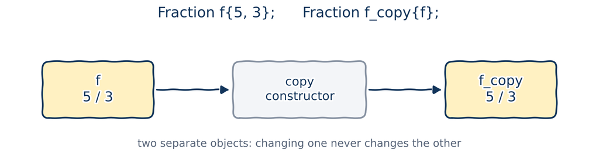

- A **copy constructor** initializes a new object from an existing object of the same type.
- If you don’t write one, the compiler writes a public **implicit copy constructor**, which copies every member.

## 6.4 Writing your own copy constructor

```
fraction.h
```

```cpp
#ifndef FRACTION_H
#define FRACTION_H

#include <iostream>

class Fraction {
  private:
    int numerator{0}, denominator{1};

  public:
    Fraction(int numerator = 0, int denominator = 1)
        : numerator{numerator}, denominator{denominator} {}

    Fraction(const Fraction& other) // our own copy constructor
        : numerator{other.numerator}, denominator{other.denominator} {
        std::cout << "Copy constructor called\n"; // just to prove it
    }

    void print() const { std::cout << numerator << '/' << denominator << '\n'; }
};

#endif
```

The copy constructor’s parameter is a `const` reference to another `Fraction`; it copies each member in the member initializer list.

## 6.5 Using it

```
copy_constructor_fraction.cpp
```

```cpp
#include "fraction.h"

int main() {
    Fraction f{5, 3};
    Fraction f_copy{f}; // calls Fraction(const Fraction&)
    f_copy.print();
    return 0;
}
```

```
Copy constructor called
5/3
```

The `Fraction` class now lives in `fraction.h`, so the next examples can simply `#include` it.

## 6.6 Copy constructor rules

**TipBest practice**

- Prefer the **implicit** copy constructor, unless you have a specific reason to write your own.
- A copy constructor should only copy, with **no side effects**: the compiler is allowed to skip calling it (next slides!).
- Its parameter should be a **`const` reference**: `Fraction(const Fraction& other)`.

Why must the parameter be a reference? If it were passed **by value**, calling the copy constructor would first need to copy the argument… using the copy constructor, which would first need to copy its argument… forever. The compiler refuses to compile that.

## 6.7 Pass by value calls the copy constructor

```
copy_constructor_pass_by_value.cpp
```

```cpp
#include "fraction.h"

void print_fraction(Fraction f) { // f is passed by value
    f.print();
}

int main() {
    Fraction f{5, 3};
    print_fraction(f); // f is copied into the parameter
    return 0;
}
```

```
Copy constructor called
5/3
```

Passing by value copies the argument into the parameter (Chapter 02), and for a class type that copy is made by the copy constructor. Another reason to pass class objects by `const` reference!

## 6.8 Return by value and copy elision

```
copy_constructor_return_by_value.cpp
```

```cpp
#include "fraction.h"

void print_fraction(Fraction f) { f.print(); } // a copy each time

Fraction make_fraction(int n, int d) {
    Fraction f{n, d};
    return f; // a copy here too? (spoiler: no)
}

int main() {
    Fraction f1{};
    print_fraction(f1);
    Fraction f2{make_fraction(1, 2)};
    print_fraction(f2);
    Fraction f3{make_fraction(4, 2)};
    print_fraction(f3);
    return 0;
}
```

```
Copy constructor called
0/1
Copy constructor called
1/2
Copy constructor called
4/2
```

In principle there are **five** copies: three into `print_fraction()`’s parameter and two for `return f;`. The output shows only three. The compiler skipped the copies in `return f;`, constructing `f` directly in the caller’s object. This is **copy elision**.

## 6.9 `= default` and `= delete` for copying

Ask for the implicit copy constructor explicitly, or forbid copying altogether:

```cpp
Fraction(const Fraction& other) = default; // "the usual copy, please"
Fraction(const Fraction& other) = delete;  // "no copies allowed"
```

With `= delete`, any attempt to copy is a compile error:

```
error: use of deleted function 'Fraction::Fraction(const Fraction&)'
```

Try both yourself: `default_copy_constructor_using_default.cpp` and `remove_copy_constructor_using_delete.cpp` are on GitHub and Moodle.

# 7 Wrapping up

## 7.1 Summary

- `public` members can be used by anyone; `private` members only by the class’s own members. Access is per **class**, not per object.
- Access specifiers set the access level; `struct` defaults to `public`, `class` to `private`.
- Select members with `.` through objects and references, and with `->` through pointers.
- A **constructor** sets up a new object. It has the class’s name and no return type. Initialize members in the **member initializer list**.
- A **default constructor** takes no arguments. Writing any constructor removes the implicit one; `= default` brings it back.
- The **copy constructor** makes an object from another of the same type. It’s used when passing by value, and often skipped on return (copy elision).

## 7.2 Keep learning

Explore these on your own, with Google Gemini in Guided Learning mode or on learncpp.com:

1. [Public and private members and access specifiers](https://www.learncpp.com/cpp-tutorial/public-and-private-members-and-access-specifiers/)
2. [Constructor member initializer lists](https://www.learncpp.com/cpp-tutorial/constructor-member-initializer-lists/)
3. [Introduction to the copy constructor](https://www.learncpp.com/cpp-tutorial/introduction-to-the-copy-constructor/)
4. [Class initialization and copy elision](https://www.learncpp.com/cpp-tutorial/class-initialization-and-copy-elision/)

**Next up, Chapter 12:** more about classes, including the `this` pointer in depth and destructors.